# Lecture 27: Sample Means

### Demo: The Influence of Sample Size

Notice how the sample size impacts the distribution of sample averages.

```python
delay_mean = np.mean(sfo.column('ARR_DELAY'))
delay_sd = np.std(sfo.column('ARR_DELAY'))
delay_mean, delay_sd
```

```
(1.0869565217391304, 51.865781862374682)
```

```python
"""Empirical distribution of random sample means"""

def plot_and_summarize_sample_means(sample_size):
    sample_means = ten_thousand_sample_means(sample_size)
    sample_means_tbl = Table().with_column('Sample Means', sample_means)

    # Print some information about the distribution of the sample means
    print("Sample size: ", sample_size)
    print("Population mean:", delay_mean)
    print("Average of sample means: ", np.mean(sample_means))
    print("Population SD:", delay_sd)
    print("SD of sample means:", np.std(sample_means))

    # Plot a histogram of the sample means
    sample_means_tbl.hist(bins=20)
    plots.xlabel('Sample Means')
    plots.title('Sample Size ' + str(sample_size))
```

```
Sample size:  100
Population mean: 1.08695652174
Average of sample means:  1.21763
Population SD: 51.8657818624
SD of sample means: 5.21626480186
```

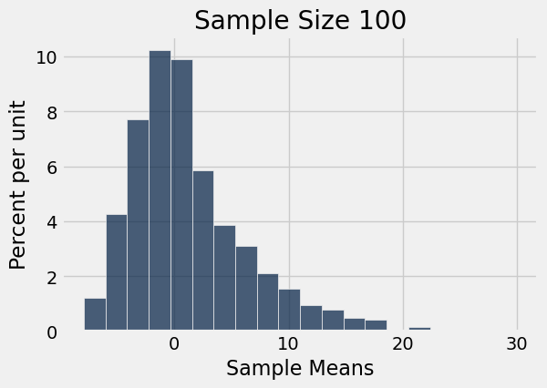

```python
plot_and_summarize_sample_means(100)
```

Observe the ratio of the population SD to the SD of the sample means.

```python
delay_sd / 5.2163    # It's around 10.
```

```
9.9430212722379228
```

```
Sample size:  400
Population mean: 1.08695652174
Average of sample means:  1.0911925
Population SD: 51.8657818624
SD of sample means: 2.49702123974
```

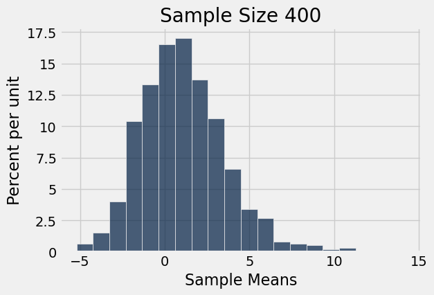

```python
plot_and_summarize_sample_means(400)
```

Observe the ratio of the population SD to the SD of the sample means.

```python
delay_sd / 2.4970  # It's around 20
```

```
20.771238230826867
```

```
Sample size:  625
Population mean: 1.08695652174
Average of sample means:  1.20464
Population SD: 51.8657818624
SD of sample means: 2.02949799476
```

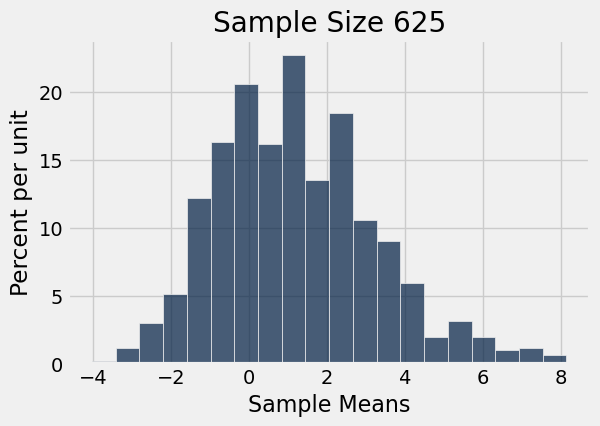

```python
plot_and_summarize_sample_means(625)
```

Observe the ratio of the population SD to the SD of the sample means.

```python
delay_sd / 2.02949   # It's around 25.
```

```
25.556066727293398
```

```
Sample size:  900
Population mean: 1.08695652174
Average of sample means:  1.06760555556
Population SD: 51.8657818624
SD of sample means: 1.70131135877
```

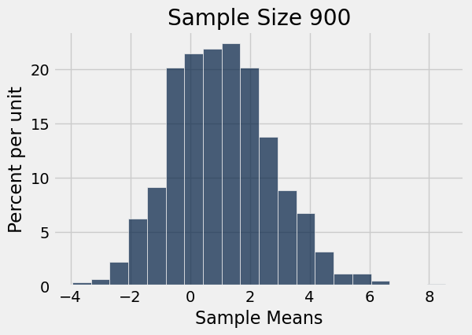

```python
plot_and_summarize_sample_means(900)
```

```python
delay_sd / 1.7013    # ratio is equal to sqrt of sample size
```

```
30.485970647372408
```

### Probability of Sample Average

- The distribution of all possible sample averages of a given size is called the distribution of the sample average.
- We approximate the distribution of sample averages by an empirical distribution.

### The Central Limit Theorem

- If
  - the sample is large and
  - drawn at random with replacement,
- Then, regardless of the distribution of the population, the probability distribution of the sample average:
  - is roughly normal
  - mean = population mean
  - SD = (population SD) / the square root of the sample size

For this theory, it is important to standardize the data.